# Project2_Mai_Todd_Carlos

# Primary EDA (Explainatory Data Analysis)

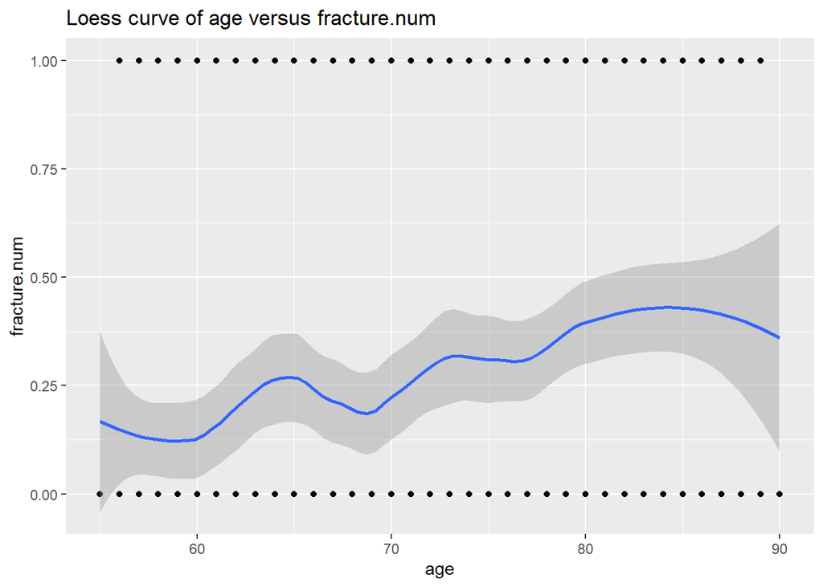

```r
#Loess curves for the numerical predictors
library(ggplot2)
#Age
ggplot(mydata,(aes(x=age,y=fracture.num)))+geom_point()+geom_smooth(method="loess",span=0.4) + ggtitle("Loess curve of age versus fracture.num")
```

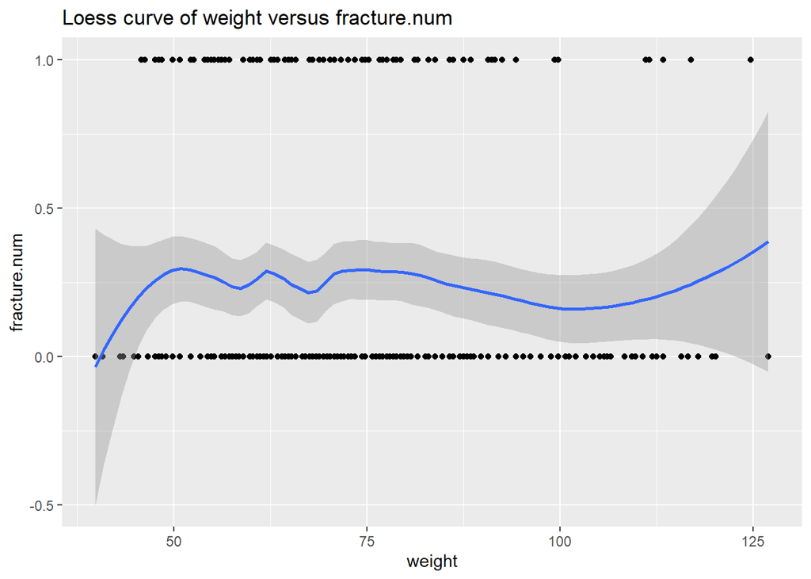

```r
#Weight
ggplot(mydata,(aes(x=weight,y=fracture.num)))+geom_point()+geom_smooth(method="loess",span=0.4) + ggtitle("Loess curve of weight versus fracture.num")
```

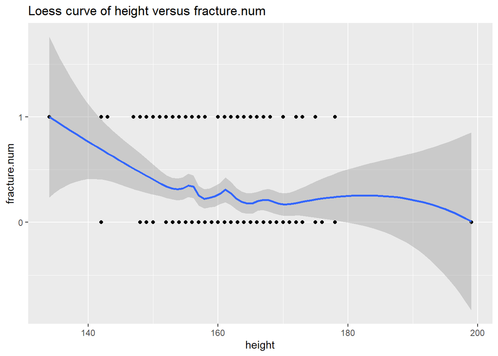

```r
#Height
ggplot(mydata,(aes(x=height,y=fracture.num)))+geom_point()+geom_smooth(method="loess",span=0.4) + ggtitle("Loess curve of height versus fracture.num")
```

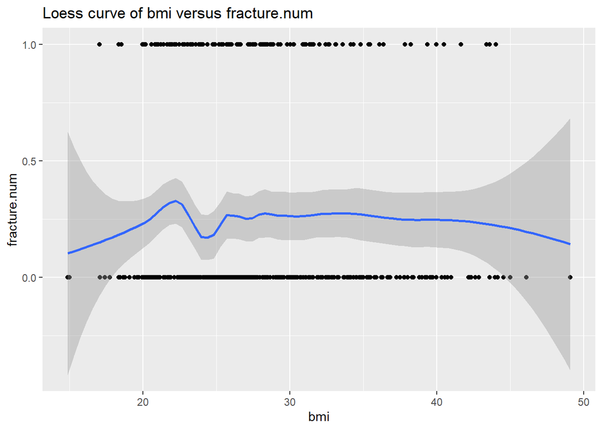

```r
#BMI
ggplot(mydata,(aes(x=bmi,y=fracture.num)))+geom_point()+geom_smooth(method="loess",span=0.4) + ggtitle("Loess curve of bmi versus fracture.num")
```

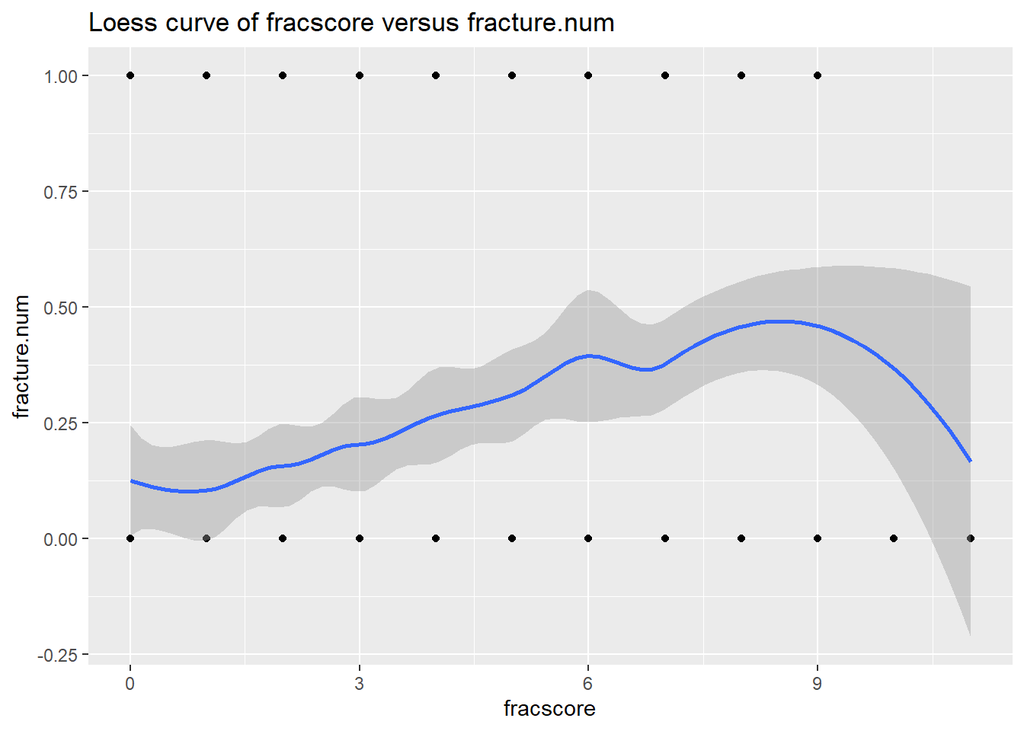

```r
#fracscore
ggplot(mydata,(aes(x=fracscore,y=fracture.num)))+geom_point()+geom_smooth(method="loess",span=0.4) + ggtitle("Loess curve of fracscore versus fracture.num")
```

# For ease of viewing, we will facet wrap the plots above into one page

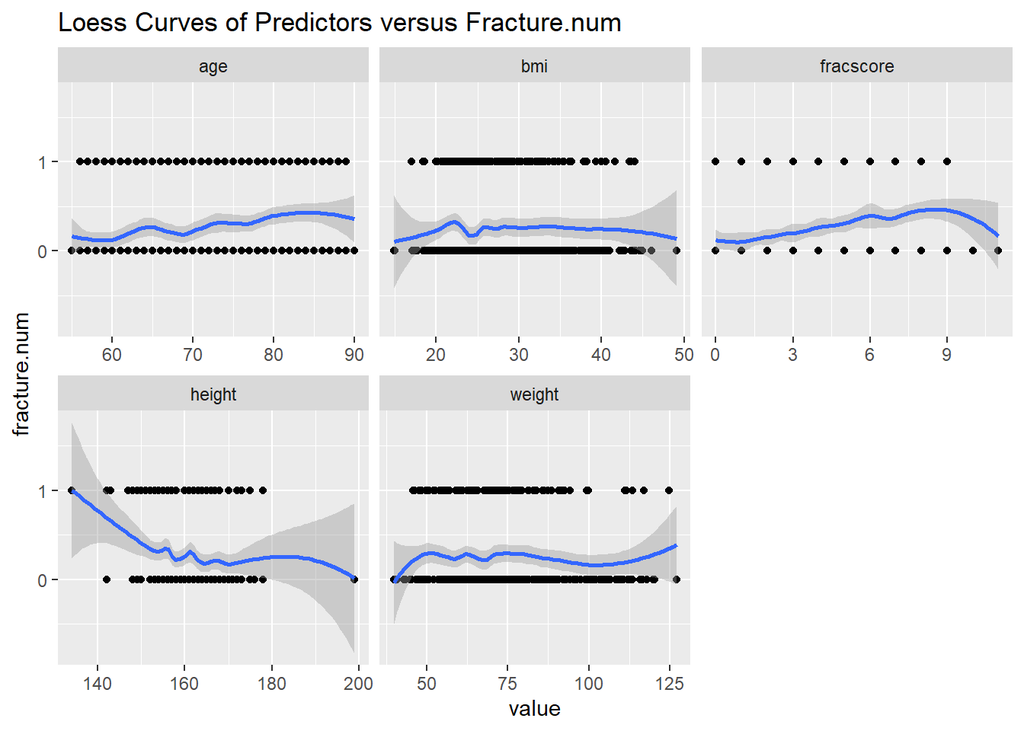

```r
library(tidyr)
library(ggplot2)

long_data <- pivot_longer(mydata,
                          cols = c(age, weight, height, bmi, fracscore),
                          names_to = "predictor",
                          values_to = "value")

ggplot(long_data, aes(x = value, y = fracture.num)) +
  geom_point() +
  geom_smooth(method = "loess", span = 0.4) +
  facet_wrap(~ predictor, scales = "free_x") +
  ggtitle("Loess Curves of Predictors versus Fracture.num")
```

According to the loess curves:

- There is a significant relationship between the age, height, and fracture score and the chances if the female patients would have at least a bone fracture within the five year study.
- There is not enough evidence to suggest there is a trend in the bmi and the weight. They may be not statistically significant in predicting whether the women would have the bone fracture within the five year study.

```r
#Barplot for the categorical predictors
library(dplyr)
g1<-mydata %>%
  group_by(priorfrac,fracture) %>%
  summarise(cnt=n()) %>%
  mutate(perc=round(cnt/sum(cnt),4))%>%
  arrange(desc(perc))
g1
```

```
## # A tibble: 4 × 4
## # Groups:   priorfrac [2]
##   priorfrac fracture   cnt  perc
##   <fct>     <fct>    <int> <dbl>
## 1 No        No         301 0.805
## 2 Yes       No          74 0.587
## 3 Yes       Yes         52 0.413
## 4 No        Yes         73 0.195
```

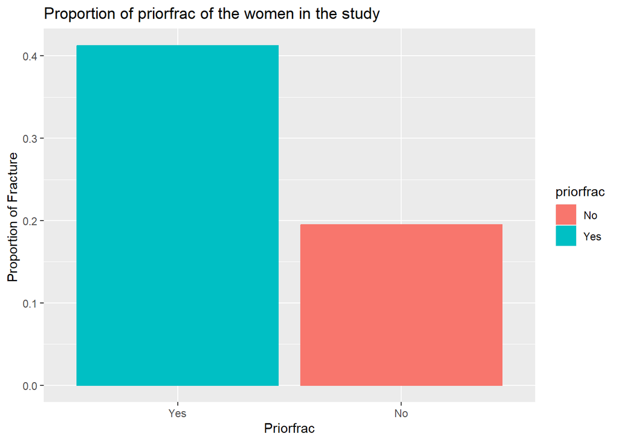

```r
ggplot(g1[c(3,4),],aes(x=reorder(priorfrac,-perc),y=perc,colour=priorfrac))+
  geom_bar(aes(fill=priorfrac),show.legend=T,stat="identity")+
  ylab("Proportion of Fracture ")+
  xlab("Priorfrac")+
  ggtitle("Proportion of priorfrac of the women in the study")
```

```r
g2<-mydata %>%
  group_by(premeno,fracture) %>%
  summarise(cnt=n()) %>%
  mutate(perc=round(cnt/sum(cnt),4))%>%
  arrange(desc(perc))
g2
```

```
## # A tibble: 4 × 4
## # Groups:   premeno [2]
##   premeno fracture   cnt  perc
##   <fct>   <fct>    <int> <dbl>
## 1 No      No         303 0.752
## 2 Yes     No          72 0.742
## 3 Yes     Yes         25 0.258
## 4 No      Yes        100 0.248
```

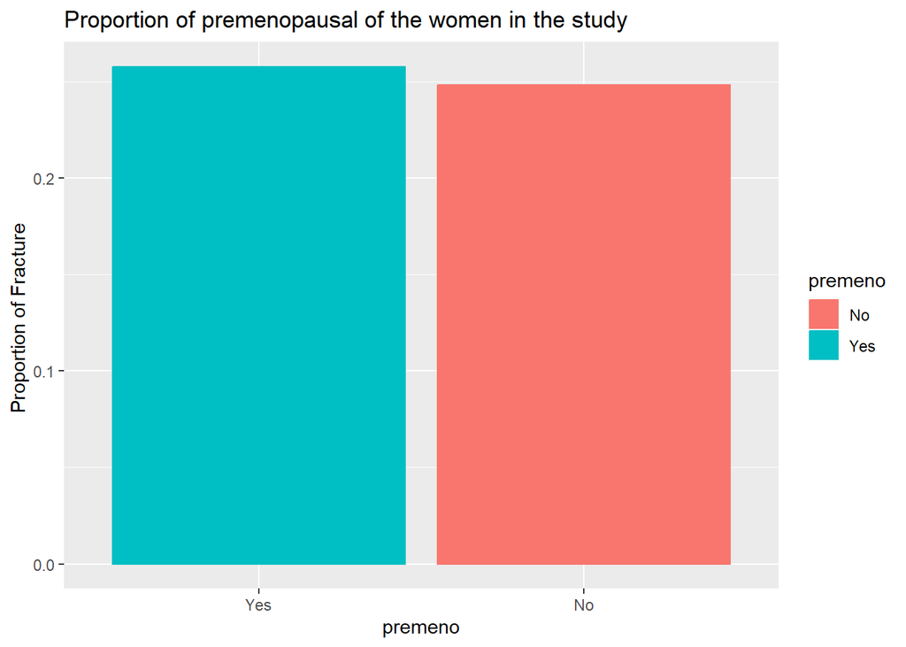

```r
ggplot(g2[c(3,4),],aes(x=reorder(premeno,-perc),y=perc,colour=premeno))+
  geom_bar(aes(fill=premeno),show.legend=T,stat="identity")+
  ylab("Proportion of Fracture ")+
  xlab("premeno")+
  ggtitle("Proportion of premenopausal of the women in the study")
```

```r
g3<-mydata %>%
  group_by(momfrac,fracture) %>%
  summarise(cnt=n()) %>%
  mutate(perc=round(cnt/sum(cnt),4))%>%
  arrange(desc(perc))
g3
```

```
## # A tibble: 4 × 4
## # Groups:   momfrac [2]
##   momfrac fracture   cnt  perc
##   <fct>   <fct>    <int> <dbl>
## 1 No      No         334 0.768
## 2 Yes     No          41 0.631
## 3 Yes     Yes         24 0.369
## 4 No      Yes        101 0.232
```